# Getting Started With the COVID-19 Data: Clustering

Michael Hahsler

2024-10-16

I use mostly tidyverse and ggplot. The focus of the analysis is Texas and Dallas County, TX.

```r
library("tidyverse")
```

```r
library("ggplot2")
library("DT")
```

# Prepare COVID 19 Cases in Texas Counties

https://console.cloud.google.com/marketplace/details/usafacts-public-data/covid19-us-cases?filter=solution-type:dataset&filter=category:covid19&id=3eaff9c5-fbaf-47bb-a441-89db1e1395ab

using the query

> ```
> SELECT *
> FROM `bigquery-public-data.covid19_usafacts.summary` covid19
> JOIN `bigquery-public-data.census_bureau_acs.county_2017_5yr` acs
> ON covid19.county_fips_code = acs.geo_id
> WHERE date = DATE_SUB(CURRENT_DATE(), INTERVAL 7 day)
> ```

**You will need newer data and probably also trend variables (change during the last week)**

```r
cases <- read_csv("COVID-19_cases_plus_census.csv")
cases
```

```
## # A tibble: 3,142 × 259
##    county_fips_code county_name state state_fips_code date       confirmed_cases
##    <chr>            <chr>       <chr> <chr>           <date>               <dbl>
##  1 50009            Essex Coun… VT    50              2021-01-19             111
##  2 50007            Chittenden… VT    50              2021-01-19            3636
##  3 10001            Kent County DE    10              2021-01-19           11548
##  4 44009            Washington… RI    44              2021-01-19            5521
##  5 33001            Belknap Co… NH    33              2021-01-19            2496
##  6 44005            Newport Co… RI    44              2021-01-19            3578
##  7 50015            Lamoille C… VT    50              2021-01-19             312
##  8 09013            Tolland Co… CT    09              2021-01-19            6255
##  9 50001            Addison Co… VT    50              2021-01-19             527
## 10 50005            Caledonia … VT    50              2021-01-19             307
## # ℹ 3,132 more rows
## # ℹ 253 more variables: deaths <dbl>, geo_id <chr>, nonfamily_households <dbl>,
## #   family_households <dbl>, median_year_structure_built <dbl>,
## #   rent_burden_not_computed <dbl>, rent_over_50_percent <dbl>,
## #   rent_40_to_50_percent <dbl>, rent_35_to_40_percent <dbl>,
## #   rent_30_to_35_percent <dbl>, rent_25_to_30_percent <dbl>,
## #   rent_20_to_25_percent <dbl>, rent_15_to_20_percent <dbl>, …
```

Make character factors for analysis

```r
cases <- cases %>% mutate(across(where(is.character), factor))
dim(cases)
```

```
## [1] 3142  259
```

Filter Texas

```r
cases_TX <- cases %>% filter(state == "TX")
dim(cases_TX)
```

```
## [1] 254 259
```

```r
summary(cases_TX[,1:10])
```

```
##  county_fips_code           county_name      state     state_fips_code
##  48001  :  1      Anderson County :  1   TX     :254   48     :254
##  48003  :  1      Andrews County  :  1   AK     :  0   01     :  0
##  48005  :  1      Angelina County :  1   AL     :  0   02     :  0
##  48007  :  1      Aransas County  :  1   AR     :  0   04     :  0
##  48009  :  1      Archer County   :  1   AZ     :  0   05     :  0
##  48011  :  1      Armstrong County:  1   CA     :  0   06     :  0
##  (Other):248      (Other)         :248   (Other):  0   (Other):  0
##       date            confirmed_cases      deaths            geo_id
##  Min.   :2021-01-19   Min.   :     1   Min.   :   0.00   48001  :  1
##  1st Qu.:2021-01-19   1st Qu.:   487   1st Qu.:  13.00   48003  :  1
##  Median :2021-01-19   Median :  1310   Median :  30.00   48005  :  1
##  Mean   :2021-01-19   Mean   :  8419   Mean   : 127.48   48007  :  1
##  3rd Qu.:2021-01-19   3rd Qu.:  3502   3rd Qu.:  78.75   48009  :  1
##  Max.   :2021-01-19   Max.   :286356   Max.   :3825.00   48011  :  1
##                                                          (Other):248
##  nonfamily_households family_households
##  Min.   :    12       Min.   :     19
##  1st Qu.:   674       1st Qu.:   1618
##  Median :  1883       Median :   4474
##  Mean   : 11300       Mean   :  25828
##  3rd Qu.:  4683       3rd Qu.:  12366
##  Max.   :496164       Max.   :1066649
##
```

Calculate rates (per 1000 people) so we can compare counties of different sizes and select important variables. **Note:** You will need more variables.

```r
cases_TX <- cases_TX %>%
 # filter(confirmed_cases > 100) %>%
  arrange(desc(confirmed_cases)) %>%
  select(county_name, confirmed_cases, deaths, total_pop, median_income, median_age, poverty, commuters_by_public_transportation)
cases_TX <- cases_TX %>% mutate(
  cases_per_1000 = confirmed_cases/total_pop*1000,
  deaths_per_1000 = deaths/total_pop*1000,
  death_per_case = deaths/confirmed_cases)

summary(cases_TX)
```

```
##            county_name  confirmed_cases      deaths          total_pop
##  Anderson County :  1   Min.   :     1   Min.   :   0.00   Min.   :     74
##  Andrews County  :  1   1st Qu.:   487   1st Qu.:  13.00   1st Qu.:   7072
##  Angelina County :  1   Median :  1310   Median :  30.00   Median :  18612
##  Aransas County  :  1   Mean   :  8419   Mean   : 127.48   Mean   : 107951
##  Archer County   :  1   3rd Qu.:  3502   3rd Qu.:  78.75   3rd Qu.:  49295
##  Armstrong County:  1   Max.   :286356   Max.   :3825.00   Max.   :4525519
##  (Other)         :248
##  median_income     median_age       poverty
##  Min.   :24794   Min.   :25.80   Min.   :    10
##  1st Qu.:42326   1st Qu.:34.90   1st Qu.:  1084
##  Median :48311   Median :38.55   Median :  2739
##  Mean   :49894   Mean   :39.02   Mean   : 16895
##  3rd Qu.:55741   3rd Qu.:42.90   3rd Qu.:  7554
##  Max.   :93645   Max.   :57.50   Max.   :751985
##
##  commuters_by_public_transportation cases_per_1000   deaths_per_1000
##  Min.   :    0.00                   Min.   : 13.51   Min.   :0.000
##  1st Qu.:    0.00                   1st Qu.: 58.96   1st Qu.:1.199
##  Median :   10.00                   Median : 73.94   Median :1.727
##  Mean   :  737.44                   Mean   : 77.99   Mean   :1.855
##  3rd Qu.:   56.75                   3rd Qu.: 94.10   3rd Qu.:2.394
##  Max.   :57933.00                   Max.   :182.90   Max.   :6.284
##
##  death_per_case
##  Min.   :0.00000
##  1st Qu.:0.01482
##  Median :0.02262
##  Mean   :0.02469
##  3rd Qu.:0.03087
##  Max.   :0.09322
##
```

Looks like there are no missing values to deal with.

# Used Data

This is the (somewhat) cleaned data I use for analysis. I use an interactive widget table to interactively analyze the data. The table can be used to sort the counties to find the smallest and largest values (e.g., population, cases, etc.)

```r
datatable(cases_TX) %>% formatRound(c(5, 9, 10), 2) %>% formatPercentage(11, 2)
```

|  | county_name | confirmed_cases | deaths | total_pop | median_income | median_age | poverty | commuters_by_public_transportation | cases_per_1000 | deaths_per_1000 | death_per_case |
| --- | --- | --- | --- | --- | --- | --- | --- | --- | --- | --- | --- |
| 1 | Harris County | 286356 | 3825 | 4525519 | 57791 | 33.1 | 751985 | 57933 | 63.27583642892672 | 0.8452069254377232 | 0.01335749905711771 |
| 2 | Dallas County | 234625 | 2453 | 2552213 | 53626 | 33.3 | 446611 | 34917 | 91.93002308192929 | 0.9611266771229517 | 0.01045498135322323 |
| 3 | Tarrant County | 195518 | 1798 | 1983675 | 62532 | 34.2 | 264575 | 5669 | 98.56352477094282 | 0.9063984775731911 | 0.009196084247997626 |
| 4 | Bexar County | 152231 | 2040 | 1892004 | 53999 | 33.3 | 304792 | 22716 | 80.46018930192537 | 1.07822182194118 | 0.01340068711366279 |
| 5 | El Paso County | 107552 | 1940 | 834825 | 43244 | 31.9 | 177980 | 5196 | 128.8317910939419 | 2.323840325816788 | 0.01803778637310324 |
| 6 | Collin County | 64721 | 483 | 914075 | 90124 | 36.5 | 62439 | 5295 | 70.80491206957853 | 0.5284030303859093 | 0.007462801872653389 |
| 7 | Travis County | 61468 | 626 | 1176584 | 68350 | 33.6 | 159948 | 20378 | 52.24276379756991 | 0.5320487105043075 | 0.0101841608641895 |
| 8 | Hidalgo County | 56455 | 2018 | 839539 | 37097 | 28.9 | 263891 | 960 | 67.24523816046664 | 2.40370012590243 | 0.03574528385439731 |
| 9 | Denton County | 46272 | 439 | 781321 | 80290 | 34.9 | 64503 | 3725 | 59.22277783395045 | 0.5618689373509735 | 0.00948737897648686 |
| 10 | Lubbock County | 45600 | 648 | 298042 | 49078 | 30.7 | 53614 | 1270 | 152.9985706712477 | 2.174190214801941 | 0.01421052631578947 |

[output cut: 244 more lines]

**Note:** You will need more features (variables).

Visualize some data using a map. Extract the polygon data (corner coordinates) for county names in Texas that the map knows

```r
counties_polygon <- as_tibble(map_data("county"))
counties_polygon_TX <- counties_polygon %>% dplyr::filter(region == "texas") %>%
  rename(c(county = subregion))
counties_polygon_TX
```

```
## # A tibble: 4,488 × 6
##     long   lat group order region county
##    <dbl> <dbl> <dbl> <int> <chr>  <chr>
##  1 -95.8  31.5  2492 74520 texas  anderson
##  2 -95.8  31.6  2492 74521 texas  anderson
##  3 -95.8  31.6  2492 74522 texas  anderson
##  4 -95.7  31.6  2492 74523 texas  anderson
##  5 -95.7  31.6  2492 74524 texas  anderson
##  6 -95.7  31.6  2492 74525 texas  anderson
##  7 -95.8  31.7  2492 74526 texas  anderson
##  8 -95.8  31.7  2492 74527 texas  anderson
##  9 -95.8  31.6  2492 74528 texas  anderson
## 10 -95.8  31.6  2492 74529 texas  anderson
## # ℹ 4,478 more rows
```

Make county name match map county names (lower case + remove “County”)

```r
cases_TX <- cases_TX %>% mutate(county = county_name %>%
    str_to_lower() %>% str_replace('\\s+county\\s*$', ''))
cases_TX %>% pull(county)
```

```
##   [1] "harris"        "dallas"        "tarrant"       "bexar"
##   [5] "el paso"       "collin"        "travis"        "hidalgo"
##   [9] "denton"        "lubbock"       "fort bend"     "webb"
##  [13] "montgomery"    "cameron"       "nueces"        "williamson"
##  [17] "galveston"     "brazoria"      "mclennan"      "brazos"
##  [21] "bell"          "ellis"         "potter"        "jefferson"
##  [25] "smith"         "randall"       "hays"          "johnson"
##  [29] "midland"       "wichita"       "taylor"        "ector"
##  [33] "tom green"     "kaufman"       "parker"        "guadalupe"
##  [37] "grayson"       "gregg"         "maverick"      "rockwall"
##  [41] "starr"         "comal"         "walker"        "angelina"
##  [45] "victoria"      "val verde"     "orange"        "hale"
##  [49] "anderson"      "wise"          "liberty"       "hood"
##  [53] "lamar"         "bowie"         "navarro"       "hunt"
##  [57] "henderson"     "bastrop"       "coryell"       "howard"
```

[output cut: 49 more lines]

Use a database join

```r
counties_polygon_TX <- right_join(counties_polygon_TX, cases_TX)
```

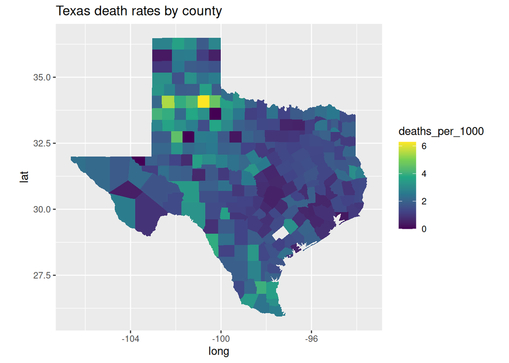

```r
ggplot(counties_polygon_TX, aes(long, lat)) +
  geom_polygon(aes(group = group, fill = deaths_per_1000)) +
  coord_quickmap() +
  scale_fill_continuous(type = "viridis") +
  labs(title = "Texas death rates by county")
```

We need to look at the missing counties.

# Cluster using k-means

Since it is unsupervised learning, I do not use the “outcome” variables. The question is: If we find counties with similar demographic composition, then they might exhibit a similar spread of the infection.

The ranges of the variables are different so I scale them to z-scores.

```r
cases_TX_scaled <- cases_TX %>%
  select(
    median_income,
    median_age,
   # total_pop, # you should use density
    poverty,
    commuters_by_public_transportation
  ) %>%
  scale() %>% as_tibble()

summary(cases_TX_scaled)
```

```
##  median_income       median_age          poverty
##  Min.   :-2.0688   Min.   :-2.21579   Min.   :-0.2618
##  1st Qu.:-0.6238   1st Qu.:-0.69047   1st Qu.:-0.2452
##  Median :-0.1305   Median :-0.07866   Median :-0.2195
##  Mean   : 0.0000   Mean   : 0.00000   Mean   : 0.0000
##  3rd Qu.: 0.4819   3rd Qu.: 0.65048   3rd Qu.:-0.1449
##  Max.   : 3.6060   Max.   : 3.09769   Max.   :11.3992
##  commuters_by_public_transportation
##  Min.   :-0.1577
##  1st Qu.:-0.1577
##  Median :-0.1556
##  Mean   : 0.0000
##  3rd Qu.:-0.1456
##  Max.   :12.2337
```

Checking again. No missing data!

I try 3 clusters and do 10 random restarts to get a better result.

```r
km <- kmeans(cases_TX_scaled, centers = 3, nstart = 10)
km
```

```
## K-means clustering with 3 clusters of sizes 145, 106, 3
##
## Cluster means:
##   median_income median_age      poverty commuters_by_public_transportation
## 1     0.2647106 -0.6599483  0.008156844                        -0.05381762
## 2    -0.3743375  0.9302074 -0.223681086                        -0.15511287
## 3     0.4322483 -0.9698292  7.509150888                         8.08183996
##
## Clustering vector:
##   [1] 3 3 1 3 1 1 1 1 1 1 1 1 1 1 1 1 1 1 1 1 1 1 1 1 1 1 1 1 1 1 1 1 1 1 1 1 1
##  [38] 1 1 1 1 1 1 1 1 1 1 1 2 1 1 2 2 1 1 1 2 1 1 1 1 1 1 1 1 1 1 1 1 2 1 2 1 1
##  [75] 1 2 1 1 1 1 1 1 1 2 1 2 2 2 2 1 2 2 1 2 1 1 1 1 1 2 1 1 2 2 2 1 1 2 1 2 2
## [112] 1 2 1 2 1 2 1 2 2 1 2 1 1 2 1 1 2 1 1 1 1 1 2 1 1 2 1 2 1 2 2 2 1 2 2 2 2
## [149] 1 2 1 1 2 2 2 1 2 2 2 2 1 2 1 2 1 1 2 1 1 1 2 1 2 2 1 2 2 2 1 1 2 2 2 2 1
## [186] 2 2 2 1 1 2 1 2 2 2 1 2 1 1 2 1 2 2 1 2 2 2 2 1 2 2 1 2 2 2 1 1 2 2 2 2 1
## [223] 2 2 2 1 2 2 2 1 2 2 2 1 2 2 2 1 2 2 2 1 2 2 1 2 1 2 2 1 1 1 1 2
##
## Within cluster sum of squares by cluster:
## [1] 298.6706 102.2141  54.4527
##  (between_SS / total_SS =  55.0 %)
##
## Available components:
##
## [1] "cluster"      "centers"      "totss"        "withinss"     "tot.withinss"
## [6] "betweenss"    "size"         "iter"         "ifault"
```

Look at cluster profiles.

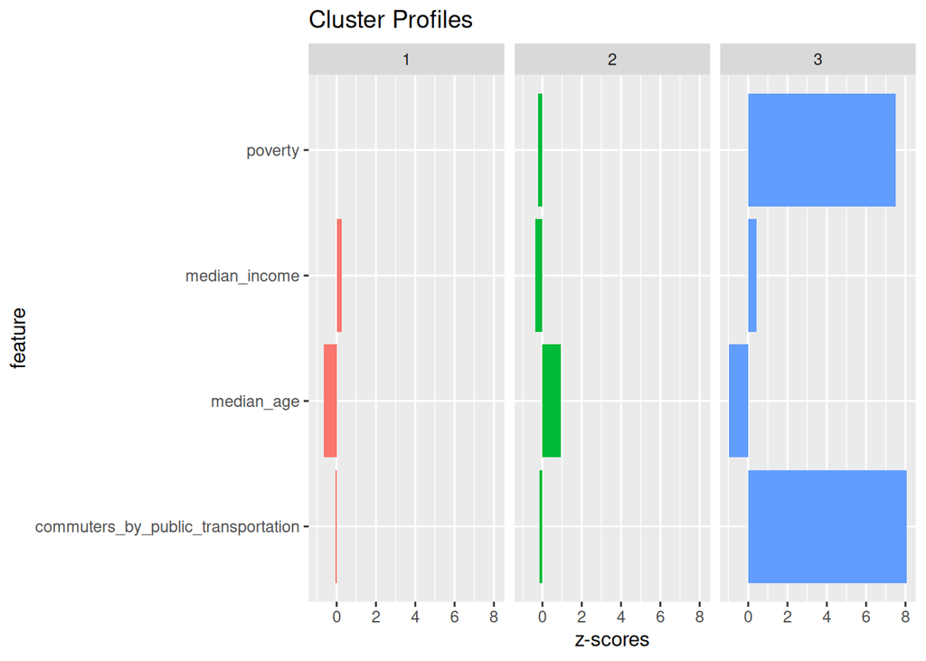

```r
ggplot(pivot_longer(as_tibble(km$centers,  rownames = "cluster"),
  cols = colnames(km$centers)),
  aes(y = name, x = value, fill = cluster)) +
  geom_bar(stat = "identity") +
  facet_grid(cols = vars(cluster)) +
  labs(y = "feature", x = "z-scores", title = "Cluster Profiles") +
  guides(fill="none")
```

Add cluster labels to the map data

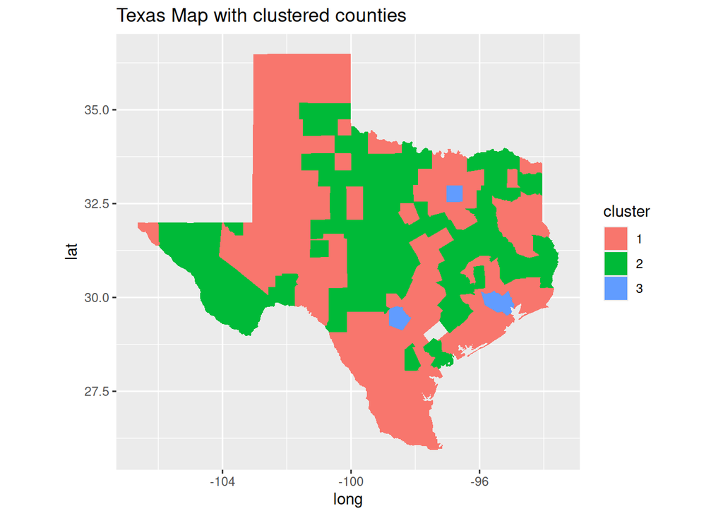

```r
cases_TX_clust <- cases_TX %>%
    add_column(cluster = factor(km$cluster))
counties_polygon_TX_clust <- right_join(counties_polygon_TX, cases_TX_clust,
                                        join_by(county))

ggplot(counties_polygon_TX_clust, aes(long, lat)) +
  geom_polygon(aes(group = group, fill = cluster)) +
  coord_quickmap() +
  labs(title = "Texas Map with clustered counties")
```

*Note:* You will need to think about how outliers affect the clustering, the appropriate number of clusters, and what the clusters mean for the decision maker.

Check if cases/deaths by 1000 people are different in different clusters:

```r
cases_TX_clust %>% group_by(cluster) %>% summarize(
  avg_cases_per_1000 = mean(cases_per_1000),
  avg_deaths_per_1000 = mean(deaths_per_1000))
```

```
## # A tibble: 3 × 3
##   cluster avg_cases_per_1000 avg_deaths_per_1000
##   <fct>                <dbl>               <dbl>
## 1 1                     84.8               1.88
## 2 2                     68.7               1.85
## 3 3                     78.6               0.962
```

*Note:* cases and deaths was not used for clustering! The clusters just represent similar demographics.

# Some questions to think about

- Do the clusters help us with identifying areas with higher risk of severe COVID-19 outbreaks?
- What other variables are important?
- Are the assumptions of k-means appropriate (Euclidean distances)?
- Other clustering algorithms?
- What can you do with the other datasets?